# Poisson example

## Example of approximations to the Poisson problem with different boundary conditions

The problem to solve is:

\[ \begin{align} -\Delta u &= f \;\;\;\;\; \text{in } \Omega \\ u &= g \;\;\;\;\; \text{in } \partial \Omega_{int} \\ \hat{n} \cdot \nabla u &= h \;\;\;\;\; \text{in } \partial \Omega_{ext} \\ \end{align} \]

For that we impose the weak version of it:

Find $u \in H^1(\Omega)$ with $u = g$ on $\partial \Omega_{int}$ such that, with $V = H^1_0(\Omega, \partial \Omega_{int})$ (the elements of $H^1(\Omega)$ vanishing on $\partial \Omega_{int}$),

\[ \int_{\Omega} \nabla v \cdot \nabla u \; d\Omega - \int_{\Omega} v \; f \; d\Omega - \oint_{\partial \Omega_{ext}} v \; h \; d\Gamma = 0 \;\;\;\;\; \forall v \;\; \in V \]

If we obtain a solution $u$ and it is sufficiently smooth, we can integrate by parts the first term and obtain:

\[ \int_{\Omega} v \; (-\Delta u - f) \; d\Omega + \oint_{\partial \Omega_{ext}} v \; (\hat{n} \cdot \nabla u - h) \; d\Gamma = 0 \;\;\;\;\; \forall v \;\; \in V \]

Taking $v$ arbitrary but of compact support inside $Ω$ we see that $u$ must satisfy:

\[ -\Delta u = f \;\;\;\;\; \text{in } \Omega, \]

taking now $v$ arbitrary but different from zero in a neighborhood of the exterior boundary, we see that it must satisfy also the Neumann condition:

\[ \hat{n} \cdot \nabla u = h \;\;\;\;\; \text{in } \partial \Omega_{ext}. \]

The Dirichlet condition is imposed directly on the space where we look for $u$.

To solve the problem we shall use the a Julia package `Gridap.jl`. This example is a mixture of several examples in the Gridap tutorial.

```julia
using Gridap
using GridapGmsh
#import Gmsh: gmsh # NEVER use #using Gmsh
mkpath("images") # output folder for the .vtu files
```

```
"images"
```

```julia
plot_s = true
if plot_s
    using GridapMakie
    if get(ENV, "CI", "false") == "true"
        using CairoMakie # the web page is built on a server without a display
    else
        using GLMakie
        GLMakie.activate!(inline=true) # For windows on the notebook itself. Comment out if you want the as pop-out plots.
    end
    using FileIO
end
```

We will use a mesh previously built with the `gmsh` library. In the `models` directory you will find a *script* with the `.geo` extension (`rectangle_hole.geo`), which was used to build the example. Based on this script, and following the `gmsh` tutorial, you can build different meshes. Other libraries can also be used to build meshes. These are imported into the **Gridap** infrastructure, and with them the triangulation to be used is constructed. Note that in the script, the two boundaries are named: the external (rectangular) one as `"ext"` and the internal (circle) one as `"int"`.

```julia
#model = GmshDiscreteModel("models/rectangle_hole_fine.msh")
model = GmshDiscreteModel("models/rectangle_hole_coarse.msh")
#model = GmshDiscreteModel("models/rectangle_hole_finer.msh")
```

```
Info    : Reading 'models/rectangle_hole_coarse.msh'...
Info    : 18 entities
Info    : 1321 nodes
Info    : 2642 elements
Info    : Done reading 'models/rectangle_hole_coarse.msh'
UnstructuredDiscreteModel()
```

```julia
Ω = Triangulation(model)
```

```
BodyFittedTriangulation()
```

```julia
degree = 2
dΩ = Measure(Ω,degree)
```

```
GenericMeasure()
```

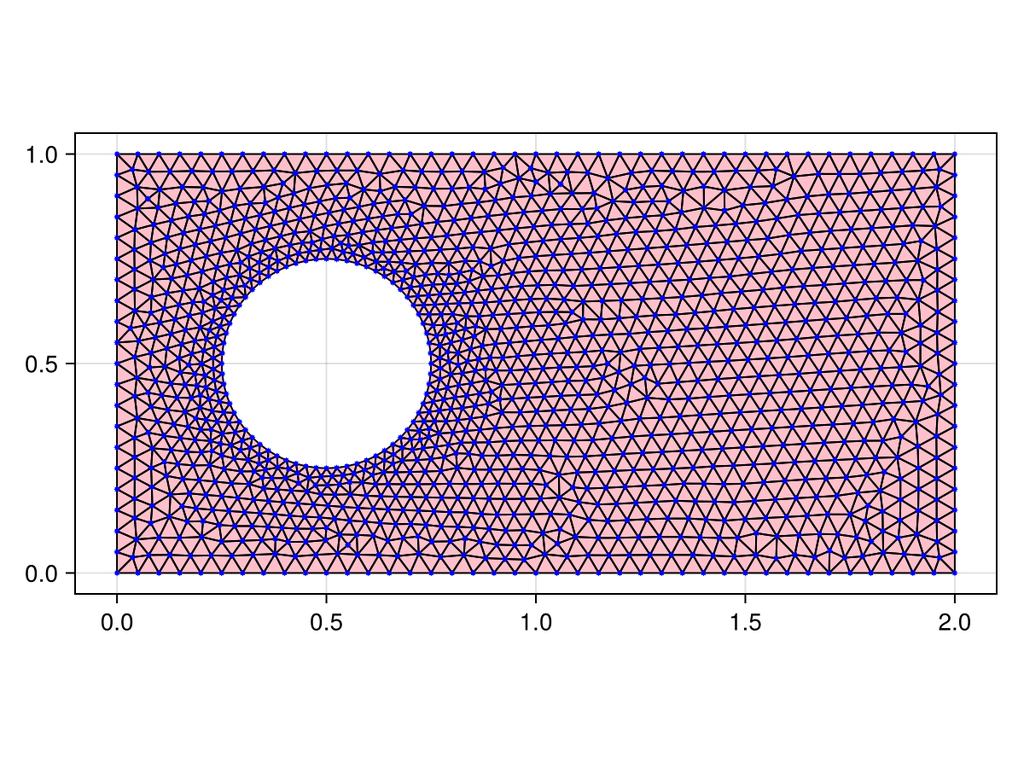

```julia
if plot_s
    fig, ax = plot(Ω)
    ax.aspect = AxisAspect(2)
    wireframe!(Ω, color=:black, linewidth=1)
    scatter!(Ω, marker=:star8, markersize=4, color=:blue)
    fig
end
```

```julia
full_dirichlet = false
int_dirichlet = false
#full_dirichlet = true
int_dirichlet = true
```

```
true
```

```julia
order = 2
reffe = ReferenceFE(lagrangian,Float64,order)
if int_dirichlet
    dirichlet_tags="int"
elseif full_dirichlet
    dirichlet_tags=["int","ext"]
end
V = TestFESpace(model,reffe;conformity=:H1,dirichlet_tags = dirichlet_tags)
```

```
UnconstrainedFESpace()
```

In this example, we are going to test our code using a *solution* given by the function $u_e(x,y) = 4((x-x_0)^2 - (y-y_0)^3) - 5y$.

Thus, $\Delta u_e = -f = 8 - 24(y-y0)$ and the Neumann condition will be given by $h = \hat{n} \cdot \nabla u_e$.

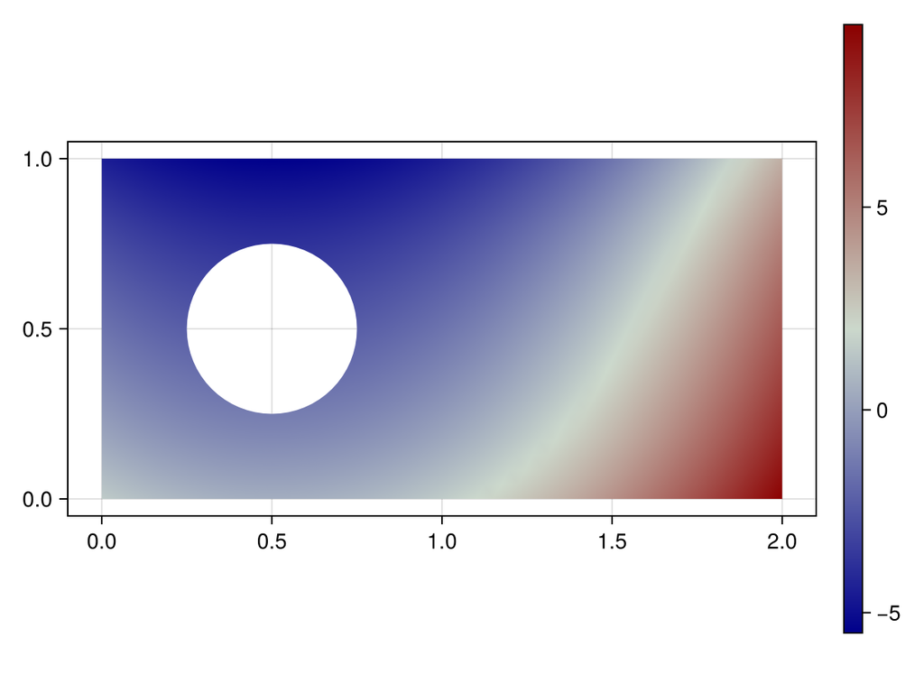

```julia
x0 = 0.5
y0 = 0.5
ue(x) = 4*((x[1]-x0)^2 - (x[2]-y0)^3) - 5.0*x[2] # "exact solution"

if plot_s
    fig, ax, plt = plot(Ω, ue, shading=false)
    ax.aspect = AxisAspect(2)
    Colorbar(fig[1,2], plt)
    fig
end
```

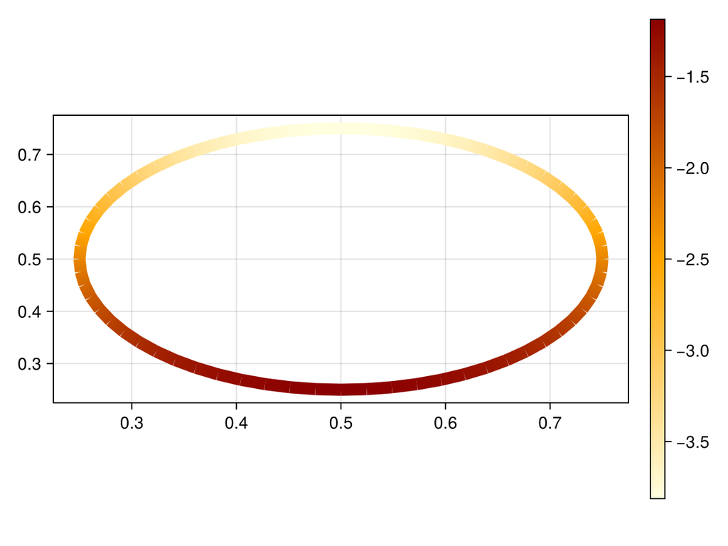

```julia
# internal Dirichlet boundary condition
U = TrialFESpace(V,ue)
Γ₁ = BoundaryTriangulation(model,tags=dirichlet_tags)
n₁ = get_normal_vector(Γ₁)

if plot_s
    fig, ax , plt  = plot(Γ₁,ue, colormap=:heat, linewidth=10)
    ax.aspect = AxisAspect(2)
    Colorbar(fig[1,2], plt)
    fig
end
```

```julia
if int_dirichlet
    neumann_tags = "ext"
    #neumanntags = "int"
    Γ = BoundaryTriangulation(model,tags=neumann_tags)
    dΓ = Measure(Γ,degree)
    nb = get_normal_vector(Γ)
end
```

```
GenericCellField():
 num_cells: 120
 DomainStyle: Gridap.CellData.ReferenceDomain()
 Triangulation: BoundaryTriangulation()
 Triangulation id: 5663611680597941700
```

To make sure every thing is OK, we plot the values of $\hat{n}\cdot \nabla u_e$ at the external boundary.

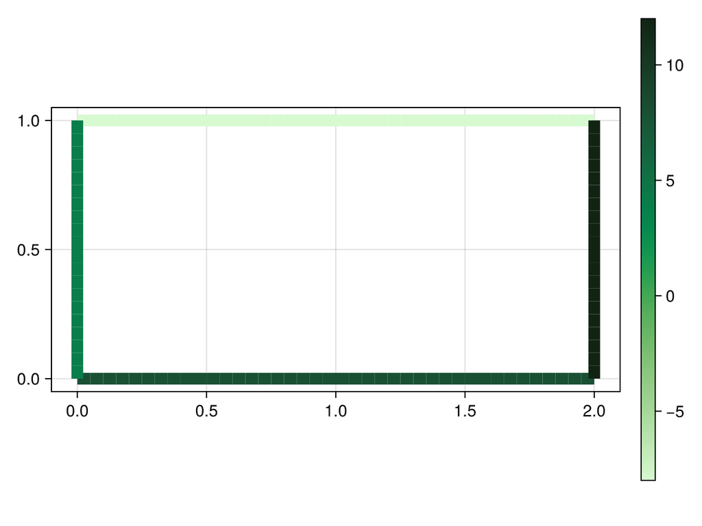

```julia
if int_dirichlet && plot_s
    fig, ax , plt = plot(Γ, (nb ⋅ ∇(ue)), colormap=:algae, linewidth=10)
    ax.aspect = AxisAspect(2)
    Colorbar(fig[1,2], plt)
    fig
end
```

We now define the weak problem in abstract form:

```julia
f(x) = -8.0 + 24*(x[2] - y0) # source
#h(x) =  #external Neumann bc.
a(u,v) = ∫( ∇(v)⋅∇(u) )*dΩ  #  in a(u,v) goes all the terms linear in the unknown, u.
if full_dirichlet
    b(v) = ∫(v*f )*dΩ #
elseif int_dirichlet
    b(v) = ∫(v*f )*dΩ + ∫(v*(nb ⋅ ∇(ue)))*dΓ #  here everything else.
end
```

```
b (generic function with 1 method)
```

From here the package **Gridap.jl** generates a equation system of the form $Ax=b$ and solves it for the finite element version of $u$.

```julia
op = AffineFEOperator(a,b,U,V)
```

```
AffineFEOperator()
```

```julia
ls = LUSolver()
solver = LinearFESolver(ls)
```

```
LinearFESolver()
```

```julia
uh = solve(solver,op)
```

```
SingleFieldFEFunction():
 num_cells: 2458
 DomainStyle: Gridap.CellData.ReferenceDomain()
 Triangulation: BodyFittedTriangulation()
 Triangulation id: 5445970073515772210
```

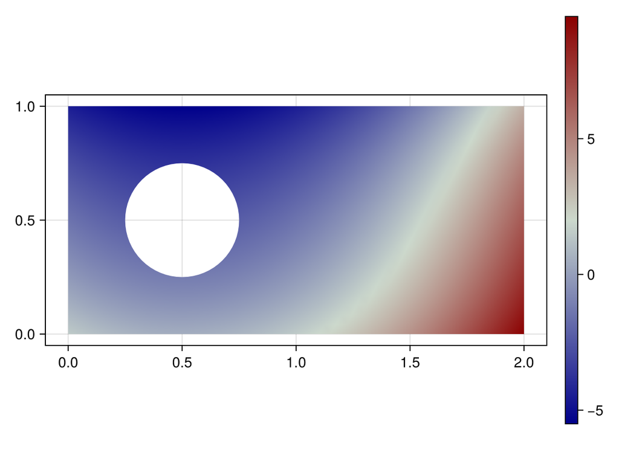

```julia
if plot_s
    fig, ax, plt = plot(Ω, uh, shading=NoShading)
    ax.aspect = AxisAspect(2)
    Colorbar(fig[1,2], plt)
    fig
end
```

```julia
if full_dirichlet
    writevtk(Ω,"images/solución_dir",cellfields=["uh_dir" => uh])
elseif int_dirichlet
    writevtk(Ω,"images/solución_newmann",cellfields=["uh_neu" => uh])
end
```

```
(["images/solución_newmann.vtu"],)
```

We now are going to validate our approximation by comparing it with the exact solution. For that we introduce several tools:

```julia
e = ue - uh
```

```
OperationCellField():
 num_cells: 2458
 DomainStyle: Gridap.CellData.ReferenceDomain()
 Triangulation: BodyFittedTriangulation()
 Triangulation id: 5445970073515772210
```

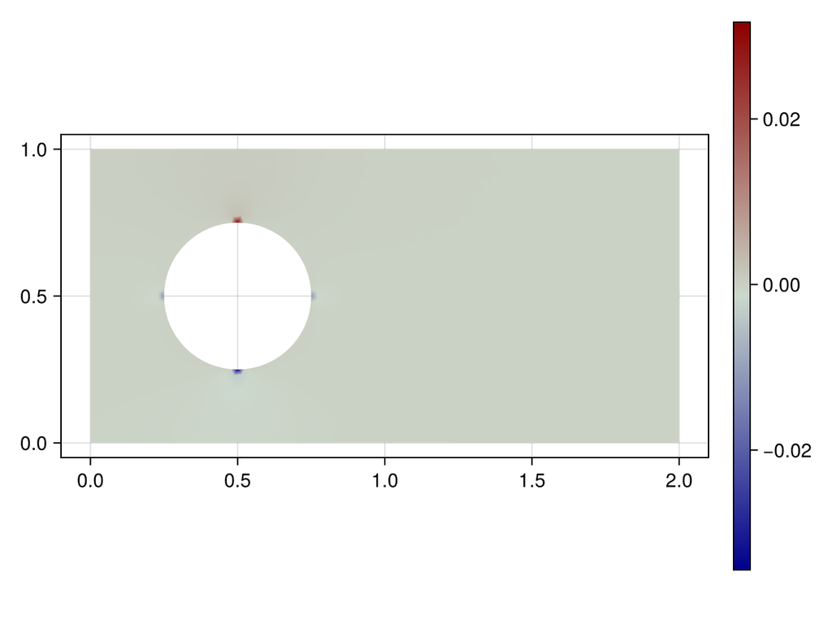

```julia
if plot_s
    fig, ax, plt = plot(Ω, e
        , shading=NoShading
        )
    ax.aspect = AxisAspect(2)
    Colorbar(fig[1,2], plt)
    fig
end
fig
```

```julia
if full_dirichlet
    writevtk(Ω,"images/error_dir",cellfields=["e_dir" => e])
elseif int_dirichlet
    writevtk(Ω,"images/error_newmann",cellfields=["e_neu" => e])
end
```

```
(["images/error_newmann.vtu"],)
```

Next we compute the $L^2$ and $H^1$ norm for the error.

```julia
el2 = sqrt(sum( ∫( e*e )*dΩ ))
println("l2 error = ",el2)
eh1 = sqrt(sum( ∫( e*e + ∇(e)⋅∇(e) )*dΩ ))
uh1 = sqrt(sum( ∫( uh*uh + ∇(uh)⋅∇(uh) )*dΩ ))
println("h1 error = ",eh1/uh1)
```

```
l2 error = 0.0005555695685049222
h1 error = 0.004664585752241493
```

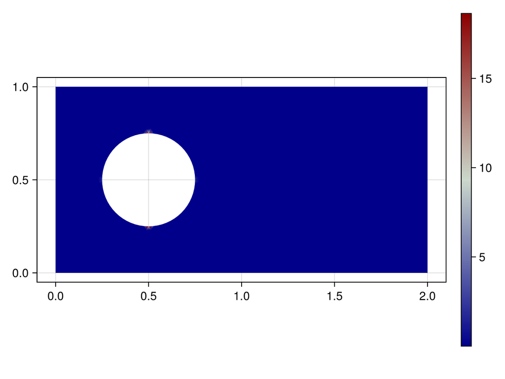

```julia
if plot_s
    fig, ax, plt = plot(Ω, ∇(e)⋅∇(e), shading=NoShading)
    ax.aspect = AxisAspect(2)
    Colorbar(fig[1,2], plt)
    fig
end
```